# Untitled

## Logistic Model 2: Simple model, all features

In the first model I will try to explain the default rate using all the variables (initial variables and additional variables)

```r
default_rec2 <- recipe(data = train, Default ~ .) %>%
  update_role(ID_var, new_role = "ID") %>%
  step_dummy(all_predictors(),one_hot = TRUE) %>%
  step_smote(Default)


glm_model <-
  workflow() %>%
  add_recipe(default_rec2) %>%
  add_model(glm_spec) %>%
  fit(data =  train)

glm_model %>%
  tidy() %>%
  kbl() %>%
  kable_classic_2(full_width = F)
```

| term | estimate | std.error | statistic | p.value |
| --- | --- | --- | --- | --- |
| (Intercept) | 3.9194116 | 0.0557443 | 70.310517 | 0.0000000 |
| Revolving_Utilization_bin_X..Inf.0.14. | -1.8435293 | 0.0220367 | -83.657087 | 0.0000000 |
| Revolving_Utilization_bin_X.0.14.0.5. | -1.2655127 | 0.0217357 | -58.222887 | 0.0000000 |
| Revolving_Utilization_bin_X.0.5.0.86. | -0.5696718 | 0.0210083 | -27.116542 | 0.0000000 |
| Revolving_Utilization_bin_X.0.86..Inf. | NA | NA | NA | NA |
| age_bin_X..Inf.44. | 0.8307512 | 0.0210363 | 39.491269 | 0.0000000 |
| age_bin_X.44.54. | 0.6672333 | 0.0219791 | 30.357678 | 0.0000000 |
| age_bin_X.54.58. | 0.3577644 | 0.0278690 | 12.837363 | 0.0000000 |
| age_bin_X.58.64. | 0.1890596 | 0.0260727 | 7.251247 | 0.0000000 |
| age_bin_X.64..Inf. | NA | NA | NA | NA |
| DebtRatio_bin_X..Inf.0.5. | -0.5985159 | 0.0227826 | -26.270803 | 0.0000000 |
| DebtRatio_bin_X.0.5.0.7. | -0.3079577 | 0.0230838 | -13.340873 | 0.0000000 |
| DebtRatio_bin_X.0.7..Inf. | NA | NA | NA | NA |
| MonthlyIncome_bin_X..Inf.4000. | 0.3076057 | 0.0195839 | 15.707036 | 0.0000000 |
| MonthlyIncome_bin_X.10000..Inf. | -0.1153834 | 0.0219745 | -5.250791 | 0.0000002 |
| MonthlyIncome_bin_X.4000.6500. | 0.1483289 | 0.0180664 | 8.210185 | 0.0000000 |
| MonthlyIncome_bin_X.6500.10000. | NA | NA | NA | NA |
| N_Open_Credit_LL_bin_X..Inf.3. | -0.3023262 | 0.0261796 | -11.548172 | 0.0000000 |
| N_Open_Credit_LL_bin_X.3.6. | -0.4437067 | 0.0174217 | -25.468669 | 0.0000000 |
| N_Open_Credit_LL_bin_X.6..Inf. | NA | NA | NA | NA |
| N_Real_Estate_LL_bin_X..Inf.1. | -0.4541944 | 0.0290580 | -15.630634 | 0.0000000 |
| N_Real_Estate_LL_bin_X.1.2. | -0.7279567 | 0.0256061 | -28.428996 | 0.0000000 |
| N_Real_Estate_LL_bin_X.2.3. | -0.6350970 | 0.0252369 | -25.165393 | 0.0000000 |
| N_Real_Estate_LL_bin_X.3..Inf. | NA | NA | NA | NA |
| N_Late_30_59_bin_X..Inf.1. | -0.1721837 | 0.0523705 | -3.287802 | 0.0010097 |
| N_Late_30_59_bin_X.1.2. | -0.0759498 | 0.0477152 | -1.591732 | 0.1114449 |
| N_Late_30_59_bin_X.2..Inf. | NA | NA | NA | NA |
| N_Late_60_89_bin_X..Inf.1. | -0.6579832 | 0.0264763 | -24.851762 | 0.0000000 |
| N_Late_60_89_bin_X.1..Inf. | NA | NA | NA | NA |
| N_Late_90_bin_X..Inf.1. | -1.1204719 | 0.0284117 | -39.436979 | 0.0000000 |
| N_Late_90_bin_X.1..Inf. | NA | NA | NA | NA |
| N_Dependents_bin_X..Inf.1. | -0.1480235 | 0.0208858 | -7.087282 | 0.0000000 |
| N_Dependents_bin_X.1.2. | -0.1374927 | 0.0229173 | -5.999509 | 0.0000000 |
| N_Dependents_bin_X.2.3. | -0.1431598 | 0.0237410 | -6.030059 | 0.0000000 |
| N_Dependents_bin_X.3..Inf. | NA | NA | NA | NA |
| N_Late_X_bin_X..Inf.1. | -1.5699875 | 0.0734816 | -21.365719 | 0.0000000 |
| N_Late_X_bin_X.1.2. | -0.6691184 | 0.0448946 | -14.904215 | 0.0000000 |
| N_Late_X_bin_X.2..Inf. | NA | NA | NA | NA |
| N_Late_Dummy_bin_X0 | NA | NA | NA | NA |
| N_Late_Dummy_bin_X1 | NA | NA | NA | NA |
| Rev_X_Late_bin_X..Inf.0.2. | 0.5592215 | 0.0313054 | 17.863410 | 0.0000000 |
| Rev_X_Late_bin_X.0.2.0.74. | 0.1698909 | 0.0286095 | 5.938277 | 0.0000000 |
| Rev_X_Late_bin_X.0.74..Inf. | NA | NA | NA | NA |
| Debt_X_Late_bin_X..Inf.0.02. | -0.1927716 | 0.0543905 | -3.544214 | 0.0003938 |
| Debt_X_Late_bin_X.0.02.0.52. | 0.2711335 | 0.0284714 | 9.523028 | 0.0000000 |
| Debt_X_Late_bin_X.0.52..Inf. | NA | NA | NA | NA |

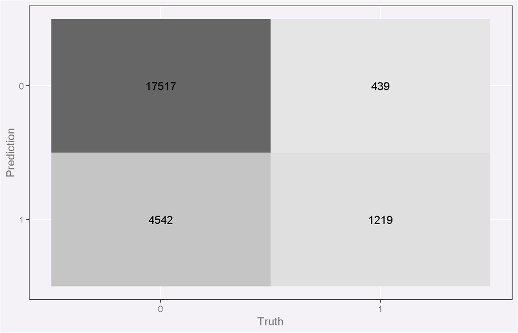

```r
glm2_pred <-
  bind_cols(
    test[,"Default"],
    predict(glm_model,test),
    predict(glm_model,test,type = "prob"))

glm2_pred %>%
  conf_mat(Default, .pred_class) %>%
  autoplot(type = "heatmap")
```

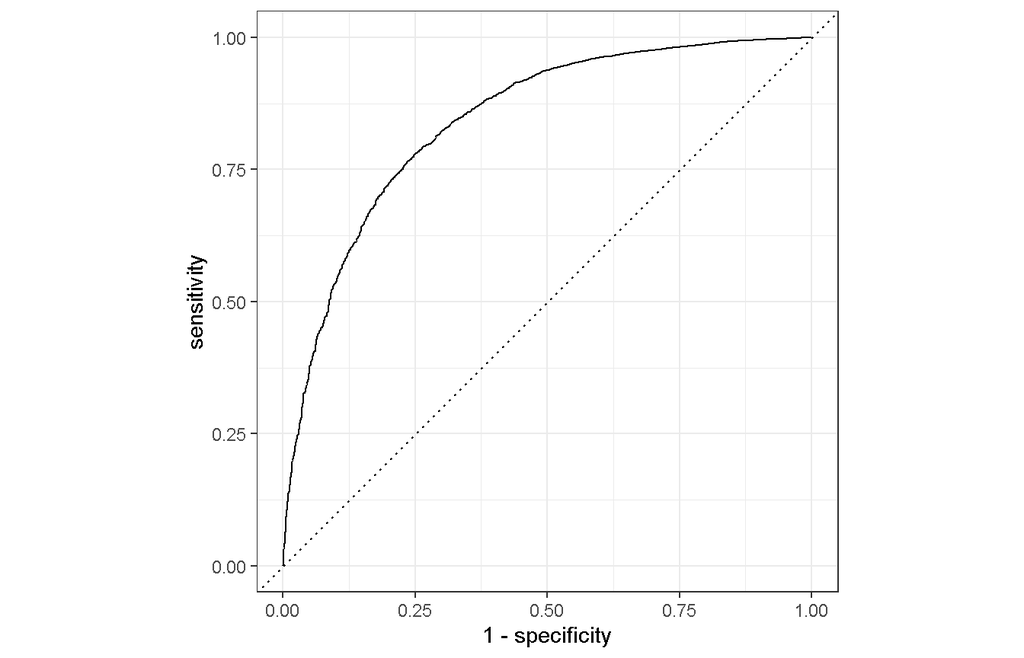

```r
roc_curve(glm_pred, truth = Default, estimate = .pred_0) %>% autoplot()
```

```r
metric_df <-
  bind_rows(bind_rows(
    accuracy(glm2_pred,Default,.pred_class),
    roc_auc(glm2_pred,Default,.pred_0)) %>%
  mutate(model = "Simple LR - All"),
  metric_df)


metric_df %>%
  filter(model == "Simple LR - All") %>%
  kbl() %>%
  kable_classic_2(full_width = F)
```

| .metric | .estimator | .estimate | model |
| --- | --- | --- | --- |
| accuracy | binary | 0.7899819 | Simple LR - All |
| roc_auc | binary | 0.8429770 | Simple LR - All |

```r
rm(glm_model,glm_spec)
```

The model with all the features is slightly better then the base model

## Penalized regression

- Let’s see if a lasso model outperforms the regular logistic regression model

```r
# Creating folds for cross validation
train_fold <- train %>% vfold_cv(3,strata = Default)

# Declaring the model we will use
lasso_spec <- logistic_reg(penalty = tune()) %>%
  set_mode("classification") %>%
  set_engine("glmnet")

lasso_model <-
  workflow() %>%
  add_recipe(default_rec2) %>%
  add_model(lasso_spec)

# Creating the specification for our tune grid
lambda_grid <- crossing(penalty = 10 ^ seq(-7,-0.5,0.25))

lasso_grid <- tune_grid(lasso_model
                        ,resamples = train_fold,
                        grid = lambda_grid,
                        control = control_grid(verbose = TRUE)
                        )
```

[output not shown]

[output not shown]

[output not shown]

[output not shown]

[output not shown]

[output not shown]

[output not shown]

[output not shown]

[output not shown]

[output not shown]

[output not shown]

[output not shown]

[output not shown]

[output not shown]

[output not shown]

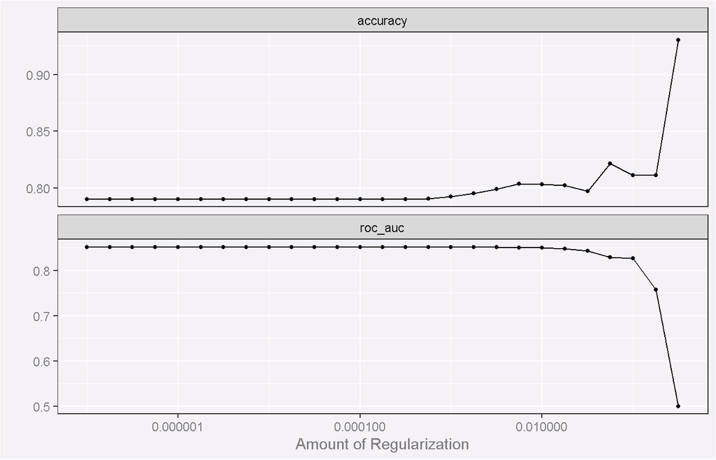

```r
highest_acc <- lasso_grid %>%
  select_best("roc_auc",maximise = TRUE)

lasso_grid %>% autoplot()
```

- We correctly identified the best preforming penalty parameter, we can fit the model to the training data

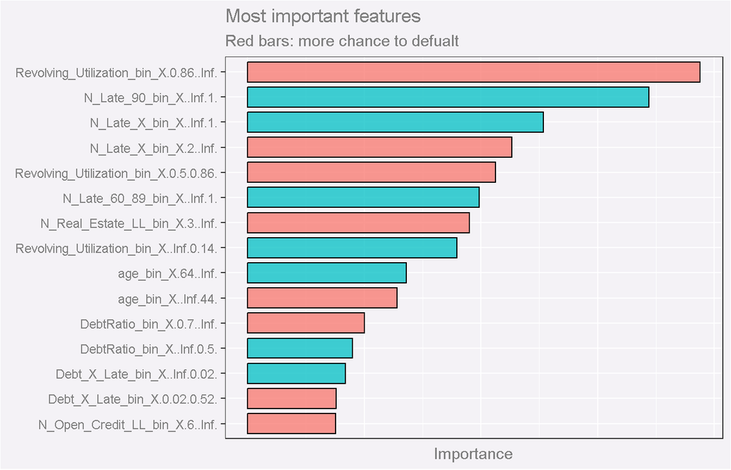

```r
# unregister_dopar <- function() {
#   env <- foreach:::.foreachGlobals
#   rm(list=ls(name=env), pos=env)
# }
#
# unregister_dopar()

# Applying the tuning to our workflow
lasso_model <- finalize_workflow(lasso_model,
                  highest_acc) %>% fit(data = train)

lasso_model %>%
  pull_workflow_fit() %>%
  vi(lambda = highest_acc$penalty) %>%
  mutate(Importance = abs(Importance),
         Variable = fct_reorder(Variable, Importance),
         Sign = fct_rev(Sign)) %>%
  top_n(15,wt = Importance) %>%
  ggplot(aes(x = Importance, y = Variable, fill = Sign)) +
  geom_col(color = "black", width = 0.8, alpha = 0.75) +
  theme(legend.position = "none", axis.ticks.x = element_blank(),
        axis.text.x = element_blank()) +
   labs(title = "Most important features",
        subtitle = "Red bars: more chance to defualt", y = element_blank())
```

- We can see that having a high **revolving rate** contributes the most for an individual to default and **not being late in payment** is the feature that contributes the most for an individual to not default.
- Now it is time to predict default on the test set

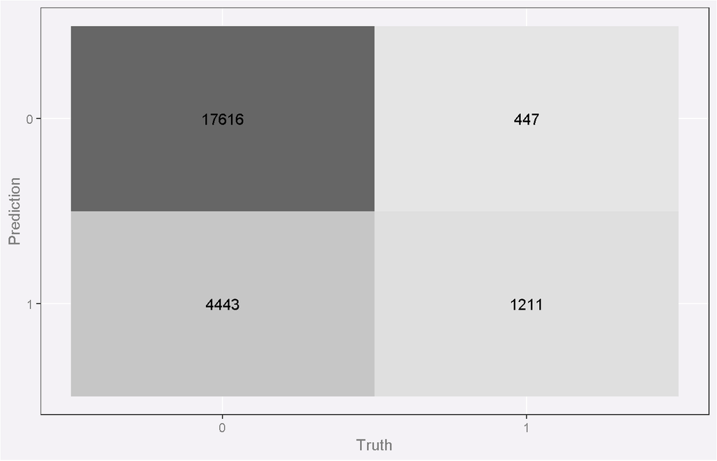

```r
lasso_pred <-
  bind_cols(
    test[,"Default"],
    predict(lasso_model,test),
    predict(lasso_model,test,type = "prob"))


lasso_pred %>%
  conf_mat(Default, .pred_class) %>%
  autoplot(type = "heatmap")
```

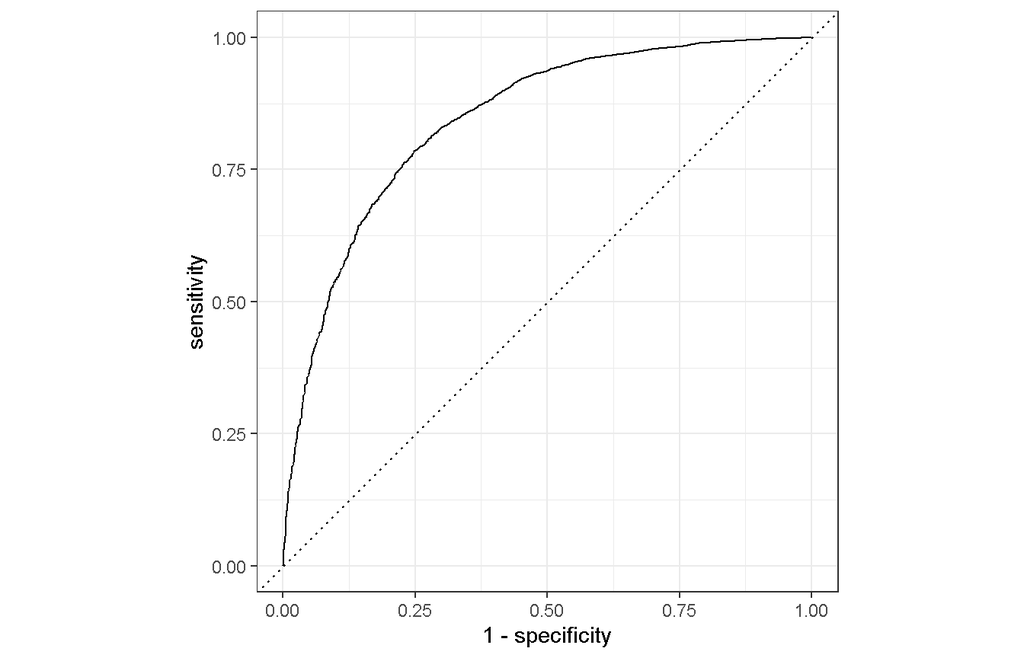

```r
roc_curve(lasso_pred, truth = Default, estimate = .pred_0) %>% autoplot()
```

```r
metric_df <-
  bind_rows(bind_rows(
    accuracy(lasso_pred,Default,.pred_class),
    roc_auc(lasso_pred,Default,.pred_0)) %>%
  mutate(model = "Lasso Regression"),
  metric_df)

metric_df %>%
  filter(model == "Lasso Regression") %>%
  kbl() %>%
  kable_classic_2(full_width = F)
```

| .metric | .estimator | .estimate | model |
| --- | --- | --- | --- |
| accuracy | binary | 0.7938188 | Lasso Regression |
| roc_auc | binary | 0.8435043 | Lasso Regression |

```r
rm(lasso_grid,lasso_spec)
```

## Random forest

Now let’s build and tune a random forest model

```r
rf_spec <- rand_forest(
  mtry = tune(),
  trees = tune(),
  min_n = tune()) %>%
  set_mode("classification") %>%
  set_engine(engine = "ranger")

rf_grid <-
  crossing(mtry = c(3,4),min_n = c(5,200),trees = c(8,16))

rf_model <-
  workflow() %>%
  add_recipe(default_rec2) %>%
  add_model(rf_spec)

rf_tune <- tune_grid(rf_model,
          resamples = train_fold,
          grid = rf_grid,
          control = control_grid(verbose = TRUE)
          )
```

[output not shown]

[output not shown]

[output not shown]

[output not shown]

[output not shown]

[output not shown]

[output not shown]

[output not shown]

[output not shown]

[output not shown]

[output not shown]

[output not shown]

[output not shown]

[output not shown]

[output not shown]

[output not shown]

[output not shown]

[output not shown]

[output not shown]

[output not shown]

[output not shown]

[output not shown]

[output not shown]

[output not shown]

[output not shown]

[output not shown]

[output not shown]

[output not shown]

[output not shown]

[output not shown]

[output not shown]

[output not shown]

[output not shown]

[output not shown]

[output not shown]

[output not shown]

[output not shown]

[output not shown]

[output not shown]

[output not shown]

[output not shown]

[output not shown]

[output not shown]

[output not shown]

[output not shown]

[output not shown]

[output not shown]

[output not shown]

[output not shown]

[output not shown]

[output not shown]

[output not shown]

[output not shown]

[output not shown]

[output not shown]

[output not shown]

[output not shown]

[output not shown]

[output not shown]

[output not shown]

[output not shown]

[output not shown]

[output not shown]

[output not shown]

[output not shown]

[output not shown]

[output not shown]

[output not shown]

[output not shown]

[output not shown]

[output not shown]

[output not shown]

[output not shown]

[output not shown]

[output not shown]

[output not shown]

[output not shown]

[output not shown]

```r
highest_acc <- rf_tune %>% select_best("roc_auc")

rf_tune %>% collect_metrics() %>% arrange(-mean)
```

```
## # A tibble: 16 × 9
##     mtry trees min_n .metric  .estimator  mean     n  std_err .config
##    <dbl> <dbl> <dbl> <chr>    <chr>      <dbl> <int>    <dbl> <chr>
##  1     4    16     5 accuracy binary     0.889     3 0.00227  Preprocessor1_Mod…
##  2     4     8     5 accuracy binary     0.887     3 0.00570  Preprocessor1_Mod…
##  3     3    16     5 accuracy binary     0.883     3 0.00357  Preprocessor1_Mod…
##  4     3     8     5 accuracy binary     0.882     3 0.00624  Preprocessor1_Mod…
##  5     3    16   200 accuracy binary     0.865     3 0.00256  Preprocessor1_Mod…
##  6     3     8   200 accuracy binary     0.865     3 0.00287  Preprocessor1_Mod…
##  7     4    16   200 accuracy binary     0.861     3 0.00498  Preprocessor1_Mod…
##  8     4     8   200 accuracy binary     0.861     3 0.00435  Preprocessor1_Mod…
##  9     3    16   200 roc_auc  binary     0.846     3 0.000391 Preprocessor1_Mod…
## 10     4    16   200 roc_auc  binary     0.844     3 0.000376 Preprocessor1_Mod…
## 11     3     8   200 roc_auc  binary     0.843     3 0.000776 Preprocessor1_Mod…
## 12     4     8   200 roc_auc  binary     0.841     3 0.000794 Preprocessor1_Mod…
## 13     3    16     5 roc_auc  binary     0.832     3 0.000796 Preprocessor1_Mod…
## 14     3     8     5 roc_auc  binary     0.822     3 0.000920 Preprocessor1_Mod…
## 15     4    16     5 roc_auc  binary     0.818     3 0.000146 Preprocessor1_Mod…
## 16     4     8     5 roc_auc  binary     0.810     3 0.00433  Preprocessor1_Mod…
```

```r
rf_model <- finalize_workflow(rf_model,
                  highest_acc) %>% fit(data = train)

rf_model %>%
  pull_workflow_fit()
```

```
## parsnip model object
##
## Ranger result
##
## Call:
##  ranger::ranger(x = maybe_data_frame(x), y = y, mtry = min_cols(~3,      x), num.trees = ~16, min.node.size = min_rows(~200, x), num.threads = 1,      verbose = FALSE, seed = sample.int(10^5, 1), probability = TRUE)
##
## Type:                             Probability estimation
## Number of trees:                  16
## Sample size:                      176468
## Number of independent variables:  45
## Mtry:                             3
## Target node size:                 200
## Variable importance mode:         none
## Splitrule:                        gini
## OOB prediction error (Brier s.):  0.1218676
```

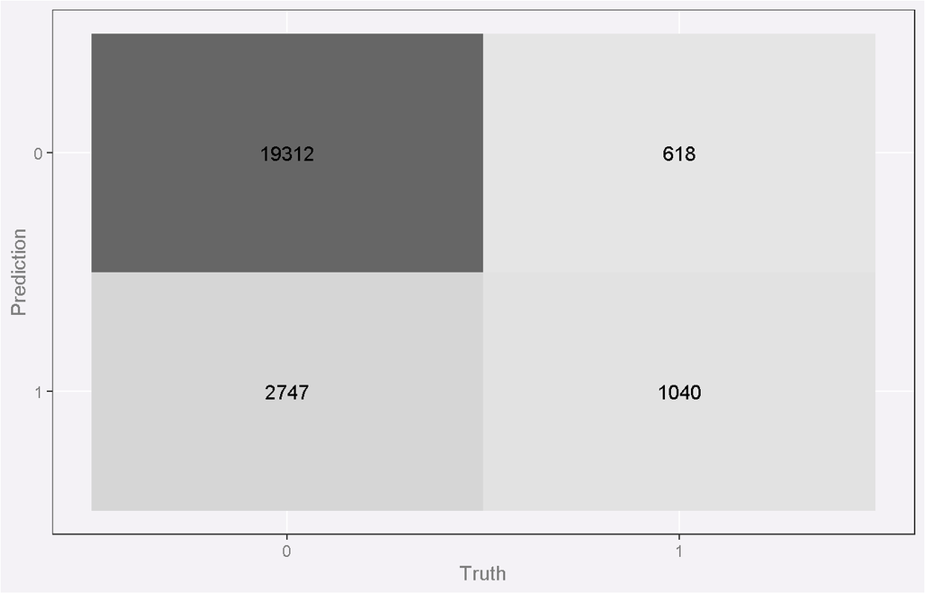

```r
rf_pred <-
  bind_cols(
    test[,"Default"],
    predict(rf_model,test),
    predict(rf_model,test,type = "prob"))

rf_pred %>%
  conf_mat(Default, .pred_class) %>%
  autoplot(type = "heatmap")
```

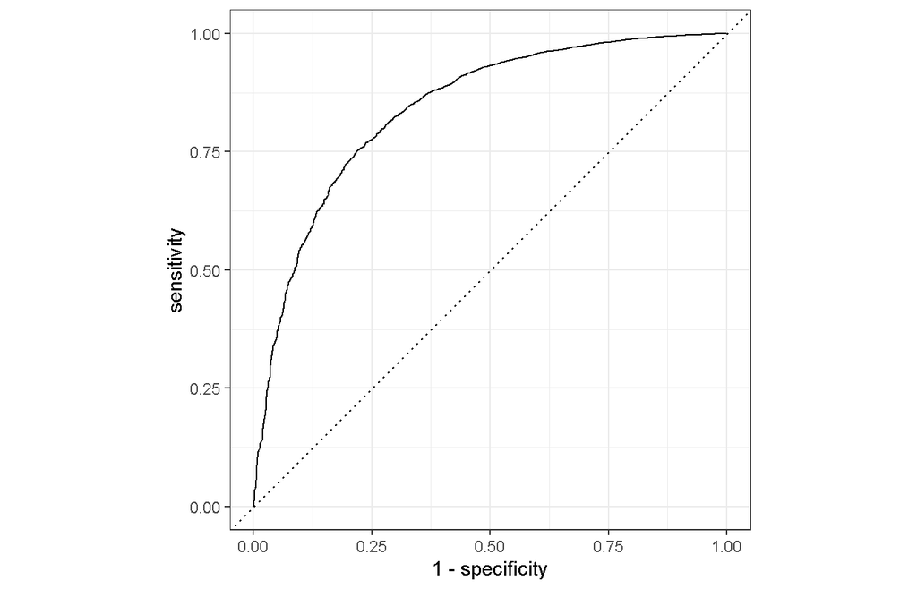

```r
roc_curve(rf_pred, truth = Default, estimate = .pred_0) %>% autoplot()
```

```r
metric_df <-
  bind_rows(bind_rows(
    accuracy(rf_pred,Default,.pred_class),
    roc_auc(rf_pred,Default,.pred_0)) %>%
  mutate(model = "Random Forest"),
  metric_df)

metric_df %>%
  filter(model == "Random Forest") %>%
  kbl() %>%
  kable_classic_2(full_width = F)
```

| .metric | .estimator | .estimate | model |
| --- | --- | --- | --- |
| accuracy | binary | 0.8581186 | Random Forest |
| roc_auc | binary | 0.8405067 | Random Forest |

## Model selection and division into HRC (Homogeneos risk classes)

- First, in order to choose which will be the model we will use we should visualize the performance metrics

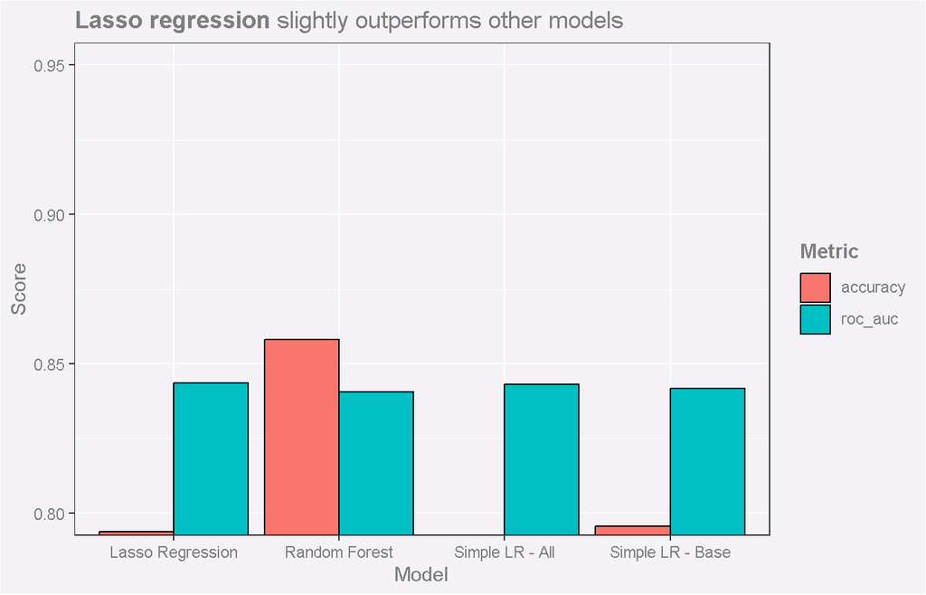

```r
metric_df %>%
  ggplot(aes(x = model,y = .estimate, fill = .metric)) +
  geom_bar(stat = "identity",position = position_dodge(),color = "black") +
  scale_y_continuous(limits = c(0.8,0.95),oob = rescale_none) +
  labs(y = "Score", x = "Model",
       title = "**Lasso regression** slightly outperforms other models") +
  guides(fill = guide_legend(title = "**Metric**"))
```

```r
head(glm2_pred,15) %>%
  kbl() %>%
  kable_classic_2(full_width = F)
```

| Default | .pred_class | .pred_0 | .pred_1 |
| --- | --- | --- | --- |
| 0 | 0 | 0.7323074 | 0.2676926 |
| 0 | 0 | 0.5770122 | 0.4229878 |
| 0 | 0 | 0.7376477 | 0.2623523 |
| 0 | 0 | 0.5421844 | 0.4578156 |
| 0 | 1 | 0.2600734 | 0.7399266 |
| 0 | 0 | 0.7037002 | 0.2962998 |
| 0 | 0 | 0.5765335 | 0.4234665 |
| 0 | 0 | 0.5744399 | 0.4255601 |
| 0 | 0 | 0.8985243 | 0.1014757 |
| 0 | 1 | 0.4011845 | 0.5988155 |
| 0 | 0 | 0.5053065 | 0.4946935 |
| 0 | 0 | 0.9291961 | 0.0708039 |
| 0 | 1 | 0.3238318 | 0.6761682 |
| 0 | 1 | 0.2679877 | 0.7320123 |
| 0 | 0 | 0.6730994 | 0.3269006 |

Using the default prediction probabilities I will compute 10 groups of risk corresponding the 10 deciles of default probabilities

```r
quantile(glm2_pred$.pred_1,probs = seq(.1, .9, by = .1))
```

```
##        10%        20%        30%        40%        50%        60%        70%
## 0.09016666 0.12223620 0.15028541 0.19126143 0.24509238 0.32672000 0.42796734
##        80%        90%
## 0.56261603 0.73972606
```

The homogeneous risk classes will be:

- HRS 1 -> less then 9% to default according to the model
- HRS 2 -> between 9% to 12.2% to default
- HRS 3 -> between 12.2% to 15% to default
- HRS 4 -> between 15% to 19.2% to default
- HRS 5 -> between 19.2% to 24.4% to default
- HRS 6 -> between 24.4% to 32.6% to default
- HRS 7 -> between 32.6% to 42.8% to default
- HRS 8 -> between 42.8% to 56.2% to default
- HRS 9 -> between 56.2% to 73.9% to default
- HRS 10 -> over 73.9% to default according to the model